# Energy Data Merge V2

Keenan Wallace

# Load Datasets

```r
train <- read_csv("data/train.csv")  #na = 528
```

```r
mapping <- read_csv("data/weather_station_to_county_mapping.csv")
historical_weather <- read_csv("data/historical_weather.csv")
client <- read_csv("data/client.csv")
gas_prices <- read_csv("data/gas_prices.csv")
electricity_prices <- read_csv("data/electricity_prices.csv")
forecast_weather <- read_csv("data/forecast_weather.csv")
```

# Data Merging

## Prepare mapping set

```r
mapping <- na.omit(mapping)
mapping$longitude <- round(mapping$longitude,1)
mapping$latitude <- round(mapping$latitude,1)
#eliminate infinite values
```

## Merge region mapping with forecast weather

```r
forecast_weather$latitude <- round(forecast_weather$latitude,1)
forecast_weather$longitude <- round(forecast_weather$longitude,1)
fweather <- left_join(forecast_weather, mapping %>% distinct(longitude, latitude, county), by = c("longitude", "latitude"))
fweather <- na.omit(fweather)
```

## Aggregate temperatures by date and region

```r
#Summarize weather data across coordinates in each county by the hour
fweather_av <- fweather %>%
  group_by(origin_datetime, forecast_datetime, county) %>%
  summarize(temperature = mean(temperature))
```

```
## can override using the `.groups` argument.
```

```r
fweather_rad <- fweather %>%
  group_by(origin_datetime, forecast_datetime, county) %>%
  summarize(direct_solar_radiation = mean(direct_solar_radiation))
```

```
## can override using the `.groups` argument.
```

```r
fweather_prec <- fweather %>%
  group_by(origin_datetime, forecast_datetime, county) %>%
  summarize(total_precipitation = mean(total_precipitation))
```

```
## can override using the `.groups` argument.
```

```r
fweather_dew <- fweather %>%
  group_by(origin_datetime, forecast_datetime, county) %>%
  summarize(dewpoint = mean(dewpoint))
```

```
## can override using the `.groups` argument.
```

```r
fweather_data_id <- fweather %>%
  group_by(origin_datetime) %>%
  summarize(data_block_id = mean(data_block_id))

# Merge the datasets into fweather_av
fweather_av$direct_solar_radiation <- fweather_rad$direct_solar_radiation
fweather_av$total_precipitation <- fweather_prec$total_precipitation
fweather_av$dewpoint <- fweather_dew$dewpoint
fweather_av <- left_join(fweather_av, fweather_data_id, by = "origin_datetime")
fweather_av <- left_join(fweather_av, fweather %>% distinct(origin_datetime, hours_ahead, forecast_datetime), by = c("origin_datetime", "forecast_datetime"))
```

## Merge forecast weather into train set

```r
fweather_av <- fweather_av %>% rename(datetime = forecast_datetime)
train <- left_join(train, fweather_av, by = c("data_block_id", "datetime", "county"))
#The combination of data_block_id and datetime in the merge ensures that only the correct datetimes for each data block are included(those which correspond to the next 24 hours of the day following the prediction time(hours_ahead == 22:45))
#This eliminates duplicates and ensures that the most recent predictions available at the prediction time are the ones that are used
```

## Merge client with train

```r
train <- left_join(train, client %>% distinct(data_block_id, is_business, county, product_type, eic_count, installed_capacity), by = c("data_block_id", "is_business", "product_type", "county"))
```

## Merge gas prices with train

```r
train <- left_join(train, gas_prices %>% distinct(data_block_id, lowest_price_per_mwh, highest_price_per_mwh), by = "data_block_id")
```

## Merge electricity prices with train

```r
electricity_prices <- separate(electricity_prices, forecast_date, c("date", "time"), sep = " ")
electricity_prices <- electricity_prices[electricity_prices$time == "10:00",]
train <- left_join(train, electricity_prices %>% distinct(data_block_id, euros_per_mwh), by = "data_block_id")
```

```r
train <- na.omit(train)
```

39946 omitted of 2018610

Note:

Because data_block_id has different starting points across datasets, the merge results in many NAs in the first couple of blocks. This resolves after block 2.

# Separate Test and Train

```r
test <- train[train$data_block_id >= 634,]
train <- train[train$data_block_id < 634,]
```

# Export sets

```r
write.csv(train, "/Users/kwallace/ISP_2024/data/train_set2.csv", row.names=FALSE)
write.csv(test, "/Users/kwallace/ISP_2024/data/test_set2.csv", row.names=FALSE)
#for use in other programs
```

# Machine Learning Models

## Looking at only energy consumption

```r
trainlm <- lm(target ~ as.factor(is_business) + temperature + direct_solar_radiation + total_precipitation + dewpoint + eic_count + installed_capacity + lowest_price_per_mwh + euros_per_mwh, data = train[train$is_consumption == 1,])

predicted <- predict(trainlm, newdata = test %>% filter(is_consumption == 1) %>% select(is_business, temperature,direct_solar_radiation, total_precipitation, dewpoint, eic_count, installed_capacity, lowest_price_per_mwh, euros_per_mwh, is_consumption))

actual <- test[test$is_consumption == 1,]$target

mae <- (1/length(actual))*sum(abs(actual - predicted))
```

mae = 444.273

## is_consumption as a predictor

```r
trainlm <- lm(target ~ as.factor(is_business) + as.factor(is_consumption) + temperature + direct_solar_radiation + total_precipitation + dewpoint + eic_count + installed_capacity + lowest_price_per_mwh + euros_per_mwh, data = train)

predicted <- predict(trainlm, newdata = test  %>% select(is_business, temperature,direct_solar_radiation, total_precipitation, dewpoint, eic_count, installed_capacity, lowest_price_per_mwh, euros_per_mwh, is_consumption))
actual <- test$target

mae_b <- (1/length(actual))*sum(abs(actual - predicted))
```

mae_b = 444.3405

Includes the full train set, yet little change in mean absolute error

### Scaling

```r
train2 <- scale(model.matrix(trainlm)[,-1], center = F)

trainlm2 <- lm(train$target ~ train2)
summary(trainlm2)
```

```
##
## Call:
## lm(formula = train$target ~ train2)
##
## Residuals:
##     Min      1Q  Median      3Q     Max
## -5131.9  -175.6   -47.6   172.7 10510.1
##
## Coefficients:
##                                   Estimate Std. Error  t value Pr(>|t|)
## (Intercept)                      -257.2986     1.4771 -174.189  < 2e-16 ***
## train2as.factor(is_business)1      -5.7032     0.7835   -7.279 3.36e-13 ***
## train2as.factor(is_consumption)1  263.4561     0.6659  395.665  < 2e-16 ***
## train2temperature                   6.6499     2.0197    3.292 0.000993 ***
## train2direct_solar_radiation       55.7578     0.7611   73.255  < 2e-16 ***
## train2total_precipitation           9.2206     0.5062   18.216  < 2e-16 ***
## train2dewpoint                    -33.0042     1.6341  -20.197  < 2e-16 ***
## train2eic_count                  -399.3169     0.9159 -436.004  < 2e-16 ***
## train2installed_capacity          964.6107     0.9227 1045.417  < 2e-16 ***
## train2lowest_price_per_mwh        -10.7594     1.5590   -6.902 5.14e-12 ***
## train2euros_per_mwh                20.4461     1.1114   18.397  < 2e-16 ***
## ---
## Signif. codes:  0 '***' 0.001 '**' 0.01 '*' 0.05 '.' 0.1 ' ' 1
##
## Residual standard error: 660.2 on 1966365 degrees of freedom
## Multiple R-squared:  0.4804, Adjusted R-squared:  0.4804
## F-statistic: 1.818e+05 on 10 and 1966365 DF,  p-value: < 2.2e-16
```

predictors with scaled estimates > 10:

is_consumption, direct_solar_radiation, dewpoint, eic_count, installed_capacity, lowest_price_per_mwh, euros_per_mwh

### Model with most significant predictors(from scaling)

```r
trainlm2 <- lm(target ~  as.factor(is_consumption) + direct_solar_radiation + dewpoint + eic_count + installed_capacity + lowest_price_per_mwh + euros_per_mwh, data = train)

predicted <- predict(trainlm2, newdata = test  %>% select(direct_solar_radiation, dewpoint, eic_count, installed_capacity, lowest_price_per_mwh, euros_per_mwh, is_consumption))
actual <- test$target

mae_bb <- (1/length(actual))*sum(abs(actual - predicted))
```

mae_bb = 444.7665

adding interaction(is_business:eic_count, is_business:installed_capacity) mae = 438.4887

- little improvement

### Diagnostics

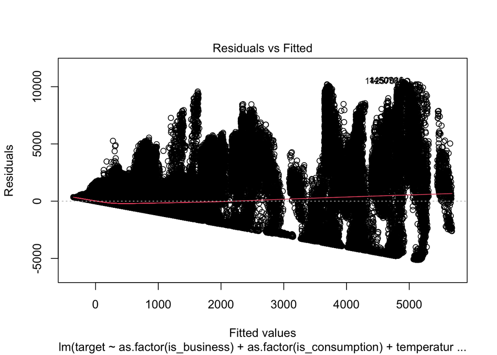

```r
plot(trainlm, which = 1)
```

Clear inequality of variance, signs of non-linearity

### Transformations

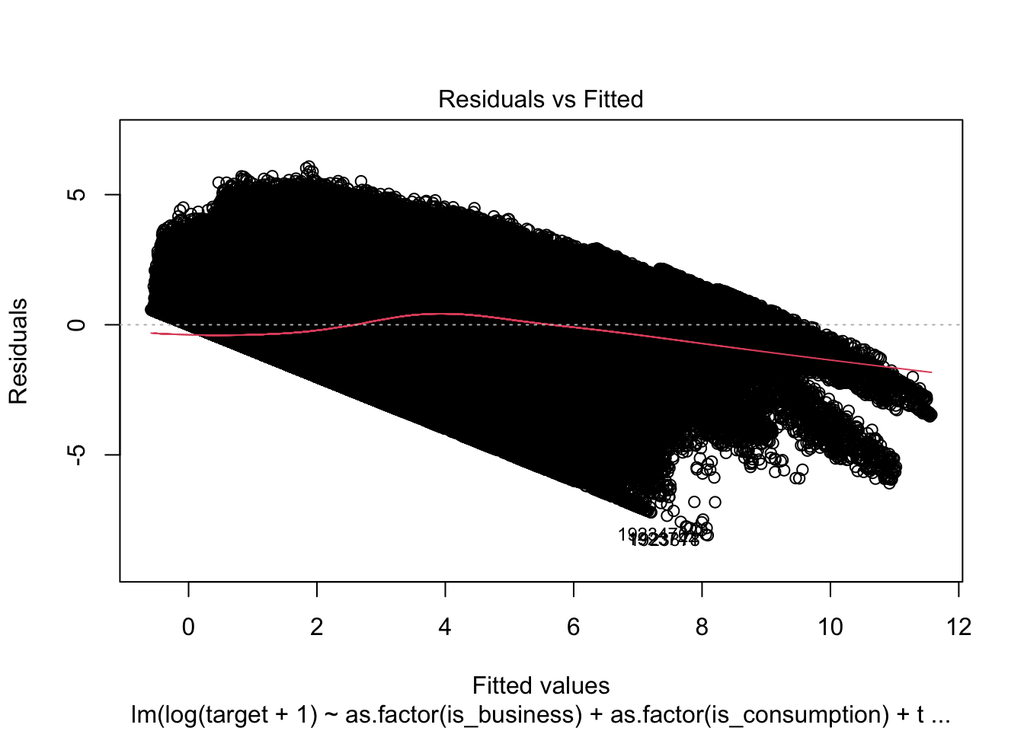

```r
trainlm <- lm(log(target+1) ~ as.factor(is_business) + as.factor(is_consumption) + temperature + as.factor(product_type) + direct_solar_radiation + total_precipitation + dewpoint + eic_count + installed_capacity + lowest_price_per_mwh + euros_per_mwh, data = train)

plot(trainlm, which = 1)
```

```r
predicted <- predict(trainlm, newdata = test  %>% select(is_business, is_consumption, temperature, direct_solar_radiation, total_precipitation, dewpoint, eic_count, installed_capacity, lowest_price_per_mwh, euros_per_mwh, product_type))

actual <- test$target

mae_blog <- (1/length(actual))*sum(abs(actual - predicted))
```

mae = 391.2793

Some improvement from log transformation

add product_type = 391.2599 (very little change)

## Log and filtered for best predictors(from scaling)

```r
trainlm2 <- lm(log(target+1) ~  as.factor(is_consumption) + direct_solar_radiation + dewpoint + eic_count + installed_capacity + lowest_price_per_mwh + euros_per_mwh, data = train)

predicted <- predict(trainlm2, newdata = test  %>% select(direct_solar_radiation, dewpoint, eic_count, installed_capacity, lowest_price_per_mwh, euros_per_mwh, is_consumption))
actual <- test$target

mae_bblog <- (1/length(actual))*sum(abs(actual - predicted))
```

mae = 391.3826 (slightly worse than normal log)

## Small ajustments

```r
trainlm <- lm(log(target+.5) ~ as.factor(is_business) + as.factor(is_consumption) + temperature + as.factor(product_type) + direct_solar_radiation + total_precipitation + dewpoint + eic_count + installed_capacity + lowest_price_per_mwh + euros_per_mwh + is_business:eic_count + is_business:installed_capacity, data = train)

predicted <- predict(trainlm, newdata = test  %>% select(is_business, temperature,direct_solar_radiation, total_precipitation, dewpoint, eic_count, installed_capacity, lowest_price_per_mwh, euros_per_mwh, is_consumption, product_type))
actual <- test$target

mae_log2 <- (1/length(actual))*sum(abs(actual - predicted))
```

log(target + .5) mae = 391.25 (no big change)

added interaction(is_business:eic_count), tiny difference mae = 391.2499

added interaction (is_business:eic_count and is_business:installed_capacity) mae = 391.2559

(slightly worse, very little difference)

## Production and consumption treated separately: random forest

production and consumption data is separated into different data frames, then trained and predicted separately and recombined before calculating MAE

```r
#random smaller train
#train reduced so that memory can accommodate the computation
set.seed(43)
production <- train[train$is_consumption ==0,] #split and recombine
consumption <- train[train$is_consumption ==1,]
smol_index_p <- sample(nrow(production), size = 25000)
smol_index_c <- sample(nrow(consumption), size = 25000)
small_train_p <- production[smol_index_p, ]
small_train_c <- consumption[smol_index_c, ]

t_production <- test[test$is_consumption ==0,] #split and recombine
t_consumption <- test[test$is_consumption ==1,]

trainrf_p <- randomForest(target ~  is_business + temperature + direct_solar_radiation + total_precipitation + dewpoint + eic_count + installed_capacity + lowest_price_per_mwh + euros_per_mwh, data = small_train_p)

trainrf_c <- randomForest(target ~ is_business + temperature + direct_solar_radiation + total_precipitation + dewpoint + eic_count + installed_capacity + lowest_price_per_mwh + euros_per_mwh, data = small_train_c)

predicted_p <- predict(trainrf_p, newdata = t_production %>% select( is_business, temperature,direct_solar_radiation, total_precipitation, dewpoint, eic_count, installed_capacity, lowest_price_per_mwh, euros_per_mwh))

predicted_c <- predict(trainrf_c, newdata = t_consumption %>% select(is_business, temperature,direct_solar_radiation, total_precipitation, dewpoint, eic_count, installed_capacity, lowest_price_per_mwh, euros_per_mwh))

predicted <- c(predicted_c, predicted_p)

actual <- c(t_consumption$target, t_production$target)

mae <- (1/length(actual))*sum(abs(actual - predicted))
```

No split(small_train = 10000 rows) mae = 252.998

No split(small_train = 20000 rows) mae = 246.6059

No split(small_train = 50000 rows) mae = 204.2338

Would likely improve if all data were utilized(see python model)

split(25000 rows each consumption, production) mae = 173.3923

Decent improvement

With log transformation(split) mae = 391.1091

Log doesn’t seem to work as well with the random forest

## Production and consumption treated separately: linear regression

```r
production <- train[train$is_consumption ==0,] #split and recombine
consumption <- train[train$is_consumption ==1,]

t_production <- test[test$is_consumption ==0,] #split and recombine
t_consumption <- test[test$is_consumption ==1,]

trainlinreg_p <- lm(log(target+1) ~  is_business + temperature + direct_solar_radiation + total_precipitation + dewpoint + eic_count + installed_capacity + lowest_price_per_mwh + euros_per_mwh, data = production)

trainlinreg_c <- lm(log(target+1) ~ is_business + temperature + direct_solar_radiation + total_precipitation + dewpoint + eic_count + installed_capacity + lowest_price_per_mwh + euros_per_mwh, data = consumption)

predicted_p <- predict(trainlinreg_p, newdata = t_production %>% select( is_business, temperature,direct_solar_radiation, total_precipitation, dewpoint, eic_count, installed_capacity, lowest_price_per_mwh, euros_per_mwh))

predicted_c <- predict(trainlinreg_c, newdata = t_consumption %>% select(is_business, temperature,direct_solar_radiation, total_precipitation, dewpoint, eic_count, installed_capacity, lowest_price_per_mwh, euros_per_mwh))

predicted <- c(predicted_c, predicted_p)

actual <- c(t_consumption$target, t_production$target)

mae <- (1/length(actual))*sum(abs(actual - predicted))
```

mae(no log transformation) = 418.021

mae(with log transformation) = 391.0707

Similar results to linear regression model without the production/consumption split